# Multiple Regression

Maria Ines Aran

20/2/2020

# Lung function and walking distance for patients with COPD

Chronic Obstructive Pulmonary disease (COPD) includes chronic bronchitis and empythsema and is caused by exposure to irritantes.

Lung functions tests check how well the lungs work. We are going to analyze the relationship between the lung function (FEV1) and predictors.

# Data

The dataset contains data on 101 patients and 24 variables such as age, gender, smoker, diabetes, hypertension and two measurments on walking distance (in meters).

```r
library(ggplot2)
library(ggthemes)
library(kableExtra)
library(tidyverse)
library(corrplot)
library("PerformanceAnalytics")
library(Hmisc)
library(sjPlot)
library(gmodels)
library(mctest)
library(prediction)
options(scipen = 999)

# Working directory
setwd("~/Documents/cursos/Health_statistics_Imperial_college")

# Read data
COPD <- read.csv('linear_data.csv')

# Size
#dim(COPD)

# Head
kable(head(COPD)[,1:12], 'html') %>%
  kable_styling(full_width = F)

kable(head(COPD)[,13:24], 'html') %>%
  kable_styling(full_width = F)
```

[output not shown]

The forced vital capacity (FVC) is a test of the total amount of air exhaled during the FEV test (Function lung). It ranges from 1.14 to 5.37 and its mean is 2.955. The histogram suggest that the distribution is not normal, this is confirmed by the Shapiro Normality test.

```r
summary(COPD$FVC)
```

```
##    Min. 1st Qu.  Median    Mean 3rd Qu.    Max.
##   1.140   2.270   2.770   2.955   3.630   5.370
```

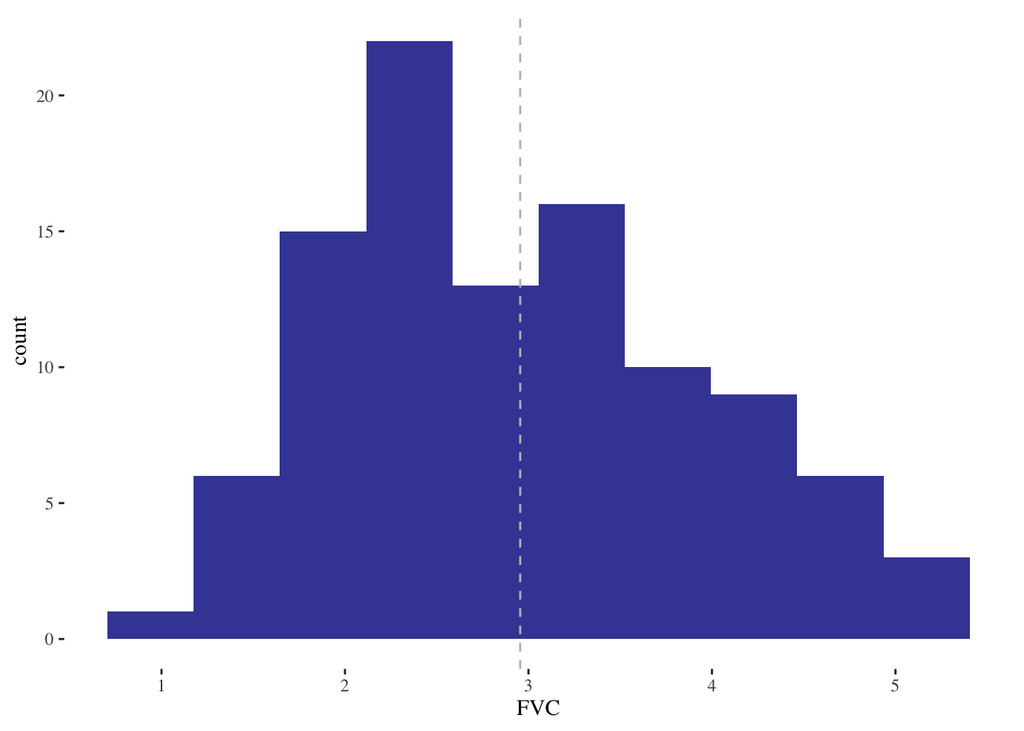

```r
# Histogram
ggplot(COPD, aes(x=FVC)) +
  geom_histogram(bins = 10, fill = 'darkblue', alpha = 0.8) +
  geom_vline(data = COPD, aes(xintercept = mean(FVC)),
             color = 'grey',
             linetype = 'dashed') +
  theme_tufte()
```

```r
# Normality test
shapiro.test(COPD$FVC)
```

```
##
##  Shapiro-Wilk normality test
##
## data:  COPD$FVC
## W = 0.96294, p-value = 0.006197
```

Shapiro Normality results in a W-statistic of 0.96294 and p-value of 0.006197. We reject the null hypothesis of normal distibution as p-value < 0.05.

# Predictors

The histograms of all the predictors show that distributions of MWT1, MWT2 and MWTBest are very similar. This is expected as MWT1 and MWT2 are walking meters by the patient and MWTBest indicates the best of both measurements. The distribution of age show that there are mainly old adults in the sample and gender is not equally distributed.

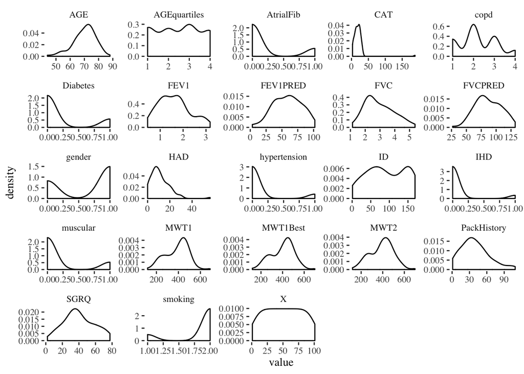

```r
COPD %>%
  keep(is.numeric) %>%                     # Keep only numeric columns
  gather() %>%                             # Convert to key-value pairs
  ggplot(aes(value)) +                     # Plot the values
    facet_wrap(~ key, scales = "free") +   # In separate panels
    geom_density() +                       # as density
  theme_tufte()
```

# Correlation tests

The correlation plot show a strong correlation betweenn MTW1, MTW2 and MTWBest1. Also there is a strong negative correlation between the outcome(FVC) and COPD.

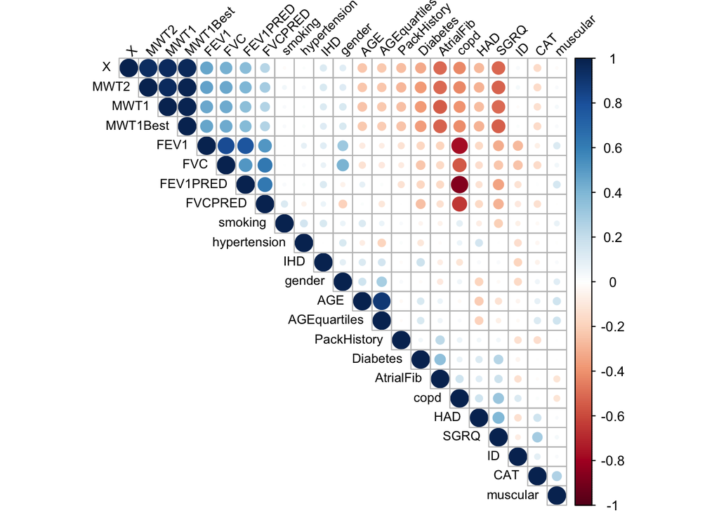

```r
# Correlation matrix
res <- cor(COPD %>% keep(is.numeric), use = 'na.or.complete')

# Correlation plot
corrplot(res, # Correlation matrix
         type = "upper", # Triangle part to display
         order = "hclust",
         tl.col = "black", tl.srt = 45,
         tl.cex = 0.75) # Font Size
```

The scatter plots show the lineal relation between walking distance measurement.

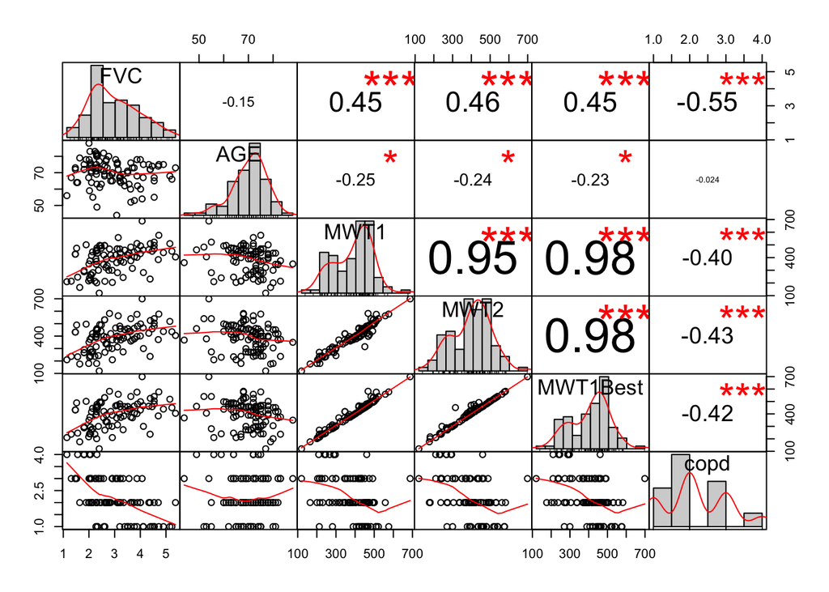

```r
# Performance analytics on selected variables

my_data <- COPD %>% select(FVC,AGE,MWT1,MWT2,MWT1Best,copd)
chart.Correlation(my_data, histogram=TRUE, pch=19)
```

# Multiple Linear Regression

First we will run simple regressions between the outcome (MWT1Best) against forced vital capacity(FVC) and age to compare results from simple regression with multiple regression.

In the simple model with age as predictor, it is statistically significant but the model fits the data poorly (Adj R-squared is 0.04). The other simple model fits the data better but still poorly (Adj. R Squared is 0.19). FVC is statistically significant and its coefficient ranges between 29.05 to 68.21.

```r
# Linear regressions
lr_age <- lm(MWT1Best ~ AGE, data = COPD)
lr_fvc <- lm(MWT1Best ~ FVC , data = COPD)
table <- sjPlot::tab_model(lr_age,lr_fvc,
                  dv.labels = c('Linear regression - Age', 'Linear Regression - FVC'),
                  p.style = 'a')
table
```

Linear regression - Age

Linear Regression - FVC

Predictors

Estimates

CI

Estimates

CI

(Intercept)

616.45 ***

431.02 – 801.88

254.95 ***

193.87 – 316.03

AGE

-3.10 *

-5.74 – -0.47

FVC

48.63 ***

29.05 – 68.21

Observations

100

100

R<sup>2</sup> / R<sup>2</sup> adjusted

0.053 / 0.043

0.199 / 0.190

- p<0.05 ** p<0.01 *** p<0.001

The multiple linear regression fits the data better than the two simple models (Adj. R square is 0.21), this means that the multivariate model explians 21% of the variance in the data. This R2 is marginally higher in this model compared with simple models. Now the age is no longer significant and ranges for FVC coefficient is smaller(26.55 to 65.56).

```r
# Multiple Linear
mlr <- lm(MWT1Best ~ AGE + FVC, data = COPD)
table <- sjPlot::tab_model(mlr,
                           p.style = 'a')
table
```

MWT 1 Best

Predictors

Estimates

CI

(Intercept)

425.38 ***

238.62 – 612.14

AGE

-2.33

-4.74 – 0.09

FVC

46.06 ***

26.55 – 65.56

Observations

100

R<sup>2</sup> / R<sup>2</sup> adjusted

0.228 / 0.212

- p<0.05 ** p<0.01 *** p<0.001

## Checking assumptions

### Collinearity

To check if there is collinearity between FVC and AGE we are going to plot the scatter plots and decide wether we need a Pearson correlation test or Spearman correlation test.

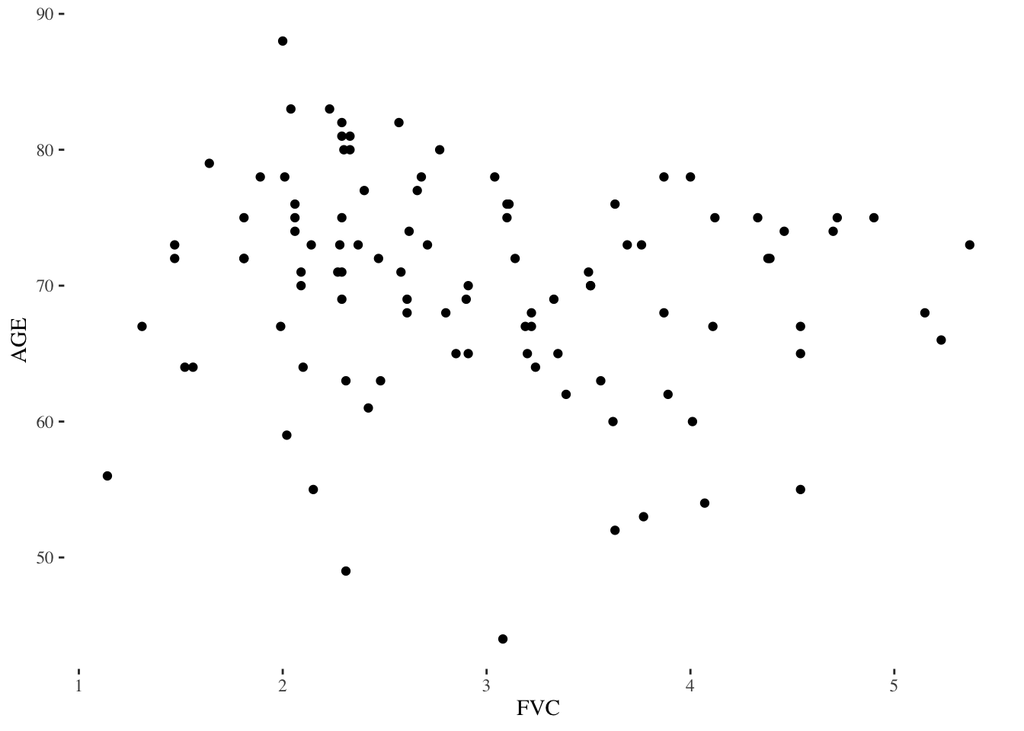

```r
ggplot(COPD, aes(x = FVC, y = AGE)) +
  geom_point() +
  theme_tufte()
```

```r
# Correlation tests
cor.test(COPD$FVC,COPD$AGE, use = 'complete.obs', method = 'pearson')
```

```
##
##  Pearson's product-moment correlation
##
## data:  COPD$FVC and COPD$AGE
## t = -1.4605, df = 99, p-value = 0.1473
## alternative hypothesis: true correlation is not equal to 0
## 95 percent confidence interval:
##  -0.33126283  0.05168036
## sample estimates:
##        cor
## -0.1452257
```

```r
cor.test(COPD$FVC,COPD$AGE, use = 'complete.obs', method = 'spearman')
```

```
##
##  Spearman's rank correlation rho
##
## data:  COPD$FVC and COPD$AGE
## S = 202110, p-value = 0.07642
## alternative hypothesis: true rho is not equal to 0
## sample estimates:
##        rho
## -0.1771108
```

Correlation between variables is -0.14 (Pearson) and -0.17(Spearman). P-value in both cases is > 0.05, the null hypothesis of not association between variables cannot be rejected so we conclude that there is no enough evidence for association between age and FVC and thus the no collinearity assumption is met.

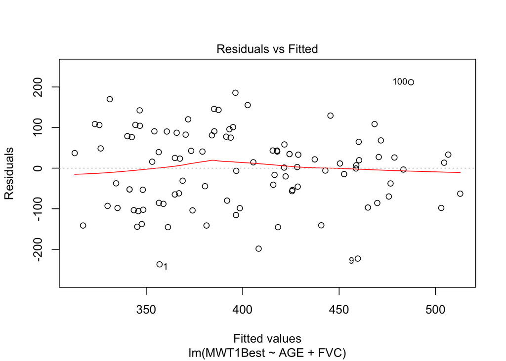

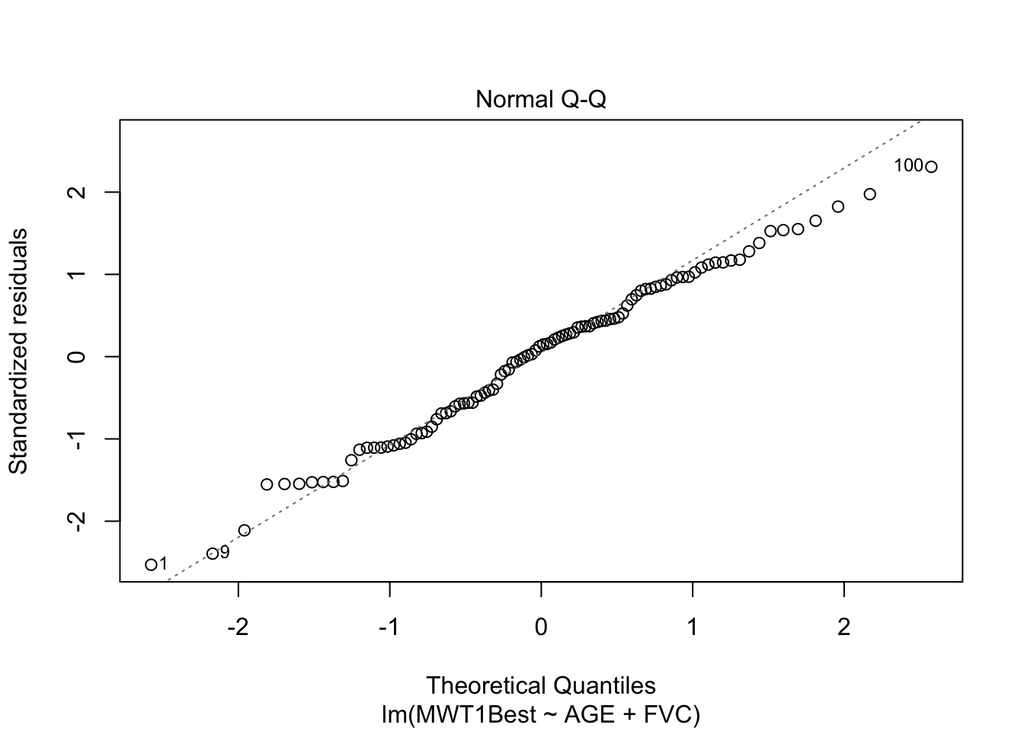

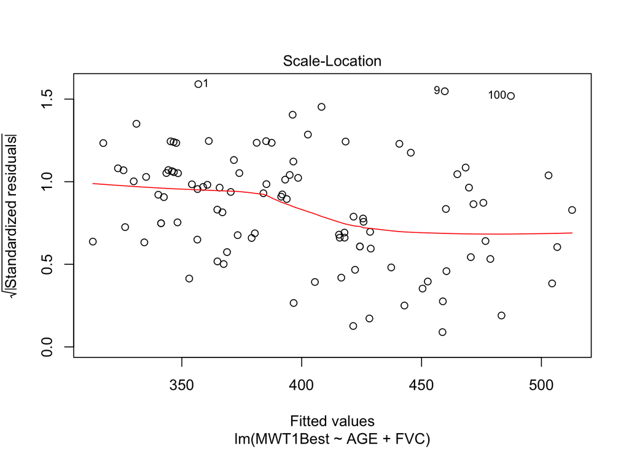

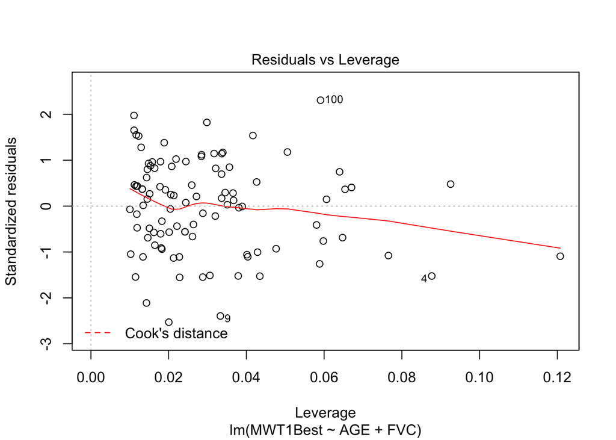

```r
# Check model assumptions
#par(mfrow=c(2,2))
plot(mlr)
```

## VIF: Variance inflation factor

It is useful when we need to measure the association across more than two variables. As spearman and pearsons correlation test only accounts for pairwise relationships.

- VIF = 1: No collinearity
- VIF > 4: Further investigation
- VIF > 10: Collinearity

# Binary variables

The binary variables should be coded as 0 and 1. 0 will be the reference category. - Female = 0 - Male = 1

The intercept (379) is the average walking distance for female.

```r
# Regression model
lr <- lm(MWT1Best ~ gender, data = COPD)
table <- sjPlot::tab_model(lr, p.style = 'a')
table
```

MWT 1 Best

Predictors

Estimates

CI

(Intercept)

379.58 ***

344.50 – 414.66

gender

30.51

-13.34 – 74.36

Observations

100

R<sup>2</sup> / R<sup>2</sup> adjusted

0.019 / 0.009

- p<0.05 ** p<0.01 *** p<0.001

# Categorical variables

One of the categories is choosen as the reference. COPD severity takes different values: ‘mild’,‘moderate’,‘severe’ and ‘very severe’.

‘Mild’ is the rerefence category and the coefficients of the other categories should be intepreted related to the reference. The regression coefficients show how much walking distance changes for moderate, severe and very severe compared to mild.

```r
# Check categories
summary(COPD$COPDSEVERITY)
```

```
##        MILD    MODERATE      SEVERE VERY SEVERE
##          23          43          27           8
```

```r
# Regression model
lr <- lm(MWT1Best ~ COPDSEVERITY, data = COPD)
table <- sjPlot::tab_model(lr,
                           p.style = 'a')
table
```

MWT 1 Best

Predictors

Estimates

CI

(Intercept)

458.09 ***

417.51 – 498.66

COPDSEVERITY [MODERATE]

-51.09 *

-101.56 – -0.61

COPDSEVERITY [SEVERE]

-89.42 **

-144.64 – -34.20

COPDSEVERITY [VERY  
SEVERE]

-167.21 ***

-247.08 – -87.34

Observations

100

R<sup>2</sup> / R<sup>2</sup> adjusted

0.179 / 0.154

- p<0.05 ** p<0.01 *** p<0.001

Now we are going to work with COPD variable as predictor. First we will change the data type to factor. The linear regression is estimated. The walking distance decresases when the COPD increases, the larger the COPD the larger the magnitud of the decrease in the outcome.

```r
# Data type
COPD$copd <- factor(COPD$copd)

# Regression
lr <- lm(MWT1Best ~ copd, data = COPD)
table <- sjPlot::tab_model(lr,
                           p.style = 'a')
table
```

MWT 1 Best

Predictors

Estimates

CI

(Intercept)

458.09 ***

417.51 – 498.66

copd [2]

-51.09 *

-101.56 – -0.61

copd [3]

-89.42 **

-144.64 – -34.20

copd [4]

-167.21 ***

-247.08 – -87.34

Observations

100

R<sup>2</sup> / R<sup>2</sup> adjusted

0.179 / 0.154

- p<0.05 ** p<0.01 *** p<0.001

```r
# Change reference category
COPD$copd <- relevel(COPD$copd, ref = 3)

# Regression
lr <- lm(MWT1Best ~ copd, data = COPD)
table <- sjPlot::tab_model(lr,
                           p.style = 'a')
table
```

MWT 1 Best

Predictors

Estimates

CI

(Intercept)

368.67 ***

331.22 – 406.12

copd [1]

89.42 **

34.20 – 144.64

copd [2]

38.33

-9.67 – 86.33

copd [4]

-77.79

-156.12 – 0.54

Observations

100

R<sup>2</sup> / R<sup>2</sup> adjusted

0.179 / 0.154

- p<0.05 ** p<0.01 *** p<0.001

# Feature engineering

A comorbid feature will be created to consider if the patient suffered at least from one of the comorbidities in the dataset: diabetes, muscular, hypertension, atrialfib and IHD.

```r
# List categorical variables
categorical <- c('Diabetes','muscular','hypertension','AtrialFib','IHD')

# Check data types
#str(COPD[,categorical])

# Transform to factors
#COPD[,categorical] <- data.frame(apply(COPD[categorical],2,as.factor))

# Check data types
#str(COPD[,categorical])

# Create comorbid
COPD <- COPD %>% mutate(comorbid = ifelse(Diabetes +
                                          muscular +
                                          hypertension +
                                          AtrialFib +
                                          IHD > 0, 1,0))
# Transform fo factor
COPD$comorbid <- factor(COPD$comorbid)
```

## Another multiple regression model

We are going to regress walking distance against age, FEV1, copd severity, comorbidity and gender. There is correlation between walking distance and FEV1(0.47.

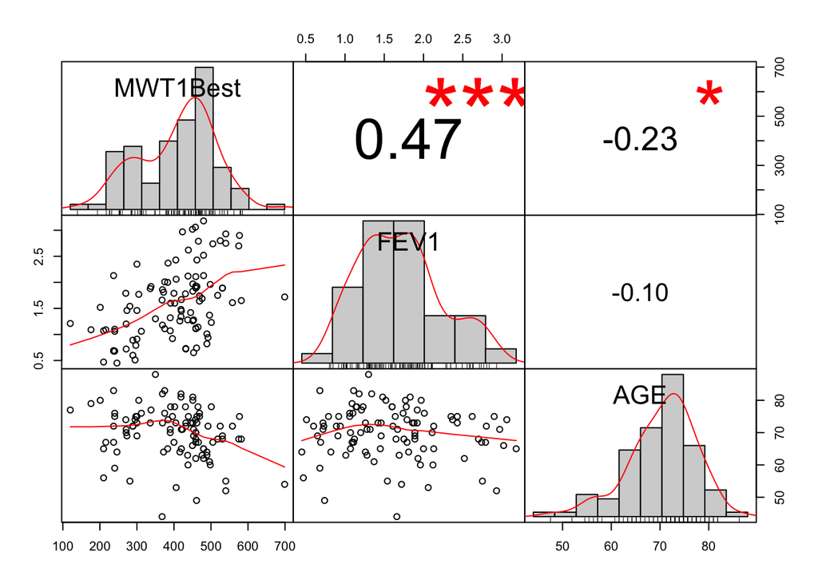

```r
# Data type transformation
COPD$gender <- factor(COPD$gender)
COPD$COPDSEVERITY <- factor(COPD$COPDSEVERITY)

# Performance analytics on selected variables
my_data <- COPD %>% select(MWT1Best,FEV1,COPDSEVERITY,gender,AGE,comorbid) %>% keep(is.numeric)
chart.Correlation(my_data, histogram=TRUE, pch=19)
```

```r
# Crosstable for categorical
CrossTable(COPD$gender,COPD$COPDSEVERITY)
```

```
##
##
##    Cell Contents
## |-------------------------|
## |                       N |
## | Chi-square contribution |
## |           N / Row Total |
## |           N / Col Total |
## |         N / Table Total |
## |-------------------------|
##
##
## Total Observations in Table:  101
##
##
##              | COPD$COPDSEVERITY
##  COPD$gender |        MILD |    MODERATE |      SEVERE | VERY SEVERE |   Row Total |
## -------------|-------------|-------------|-------------|-------------|-------------|
##            0 |           8 |          18 |           7 |           3 |          36 |
##              |       0.005 |       0.466 |       0.715 |       0.008 |             |
##              |       0.222 |       0.500 |       0.194 |       0.083 |       0.356 |
##              |       0.348 |       0.419 |       0.259 |       0.375 |             |
##              |       0.079 |       0.178 |       0.069 |       0.030 |             |
## -------------|-------------|-------------|-------------|-------------|-------------|
##            1 |          15 |          25 |          20 |           5 |          65 |
##              |       0.003 |       0.258 |       0.396 |       0.004 |             |
##              |       0.231 |       0.385 |       0.308 |       0.077 |       0.644 |
##              |       0.652 |       0.581 |       0.741 |       0.625 |             |
##              |       0.149 |       0.248 |       0.198 |       0.050 |             |
## -------------|-------------|-------------|-------------|-------------|-------------|
## Column Total |          23 |          43 |          27 |           8 |         101 |
##              |       0.228 |       0.426 |       0.267 |       0.079 |             |
## -------------|-------------|-------------|-------------|-------------|-------------|
##
##
```

```r
# Simple models
features <- c('AGE','FEV1','gender','COPDSEVERITY')

# Function to develop models
linear_model <- function(feature) {
  # capture strings and create variable
  name <- paste0('sm_',feature)
  form = lm ~ feature
  model <- lm(MWT1Best ~ COPD[[feature]], data = COPD)
  assign(name, model, envir = .GlobalEnv)
}

# Iterate features
for (feature in features){
  linear_model(feature)
}

# Make table
table <- sjPlot::tab_model(sm_AGE,sm_FEV1,sm_gender,sm_COPDSEVERITY,
                           p.style = 'a')
table
```

MWT 1 Best

MWT 1 Best

MWT 1 Best

MWT 1 Best

Predictors

Estimates

CI

Estimates

CI

Estimates

CI

Estimates

CI

(Intercept)

616.45 ***

431.02 – 801.88

279.92 ***

231.19 – 328.65

379.58 ***

344.50 – 414.66

458.09 ***

417.51 – 498.66

COPD[[feature]]

-3.10 *

-5.74 – -0.47

74.11 ***

46.15 – 102.07

COPD[[feature]]  
[COPD[[feature]]1]

30.51

-13.34 – 74.36

COPD[[feature]]  
[COPD[[feature]]MODERATE]

-51.09 *

-101.56 – -0.61

COPD[[feature]]  
[COPD[[feature]]SEVERE]

-89.42 **

-144.64 – -34.20

COPD[[feature]]  
[COPD[[feature]]VERY  
SEVERE]

-167.21 ***

-247.08 – -87.34

Observations

100

100

100

100

R<sup>2</sup> / R<sup>2</sup> adjusted

0.053 / 0.043

0.220 / 0.212

0.019 / 0.009

0.179 / 0.154

- p<0.05 ** p<0.01 *** p<0.001

The multiple regression model that includes age,gender, FEV1, COPD severities and comorbid show that the model fits the data poorly(R2 is 0.286). Age, COPD severity and comordbid are statistically significant. The patients suffering from at least one comorbidity decrease their walking distance by 45 meters compared to the ones that do not have any. One increase in age decreases the average walking distance by 3 meters. Gender and FEV1 are not statistically significant variables.

```r
mlr <- lm(MWT1Best ~ FEV1 + AGE + gender + COPDSEVERITY + comorbid, data = COPD)
table <- sjPlot::tab_model(mlr,
                           p.style = 'a')
table
```

MWT 1 Best

Predictors

Estimates

CI

(Intercept)

614.72 ***

384.68 – 844.77

FEV1

31.25

-22.45 – 84.96

AGE

-3.24 *

-5.73 – -0.74

gender [1]

29.31

-18.67 – 77.29

COPDSEVERITY [MODERATE]

-25.92

-83.53 – 31.69

COPDSEVERITY [SEVERE]

-42.69

-126.89 – 41.51

COPDSEVERITY [VERY  
SEVERE]

-134.51 *

-254.87 – -14.14

comorbid [1]

-45.28 *

-82.18 – -8.38

Observations

100

R<sup>2</sup> / R<sup>2</sup> adjusted

0.336 / 0.286

- p<0.05 ** p<0.01 *** p<0.001

### VIF

The VID method is ran to test for multicollinearity. The result suggest potentital problems with FEV1 and COPDSeverity(VIF > 4).

```r
imcdiag(model.matrix(mlr)[,-1], y = mlr$model[1] , method='VIF')
```

```
##
## Call:
## imcdiag(x = model.matrix(mlr)[, -1], y = mlr$model[1], method = "VIF")
##
##
##  VIF Multicollinearity Diagnostics
##
##                            VIF detection
## FEV1                    4.0637         0
## AGE                     1.2038         0
## gender1                 1.6584         0
## COPDSEVERITYMODERATE    2.5279         0
## COPDSEVERITYSEVERE      4.3692         0
## COPDSEVERITYVERY SEVERE 3.3343         0
## comorbid1               1.0539         0
##
## NOTE:  VIF Method Failed to detect multicollinearity
##
##
## 0 --> COLLINEARITY is not detected by the test
##
## ===================================
```

# Interactions between variables - binary

Interactions ocurr when the predictor variables has a different effec on the outcome depending on the value of another explanatory variable. - Diabetic: 0 if not, 1 otherwise - AtrialFib (atrial fibrillation): 0 if not , 1 otherwise

```r
# Data type: Integer
COPD$Diabetes <- as.integer(COPD$Diabetes)
COPD$AtrialFib <- as.integer(COPD$AtrialFib)

mlr <- lm(MWT1Best ~ factor(Diabetes) + factor(AtrialFib) + factor(Diabetes * AtrialFib),
          data = COPD)
sjPlot::tab_model(mlr,
                  p.style = 'a')
```

MWT 1 Best

Predictors

Estimates

CI

(Intercept)

428.14 ***

407.52 – 448.77

Diabetes [1]

-7.69

-63.32 – 47.94

AtrialFib [1]

-72.04 *

-130.02 – -14.07

factor(Diabetes *  
AtrialFib)1

-130.11 **

-224.80 – -35.42

Observations

100

R<sup>2</sup> / R<sup>2</sup> adjusted

0.364 / 0.344

- p<0.05 ** p<0.01 *** p<0.001

```r
# Predictions
list('diabetes' = prediction(mlr, at = list(Diabetes = c(0,1))),
     'atrialfib' = prediction(mlr, at = list(AtrialFib = c(0,1))),
     'Diabetes*Atrialfib' = prediction(mlr, at = list(Diabetes = c(0,1),
                                                      AtrialFib = c(0,1))))
```

```
## Data frame with 200 predictions from
##  lm(formula = MWT1Best ~ factor(Diabetes) + factor(AtrialFib) +
##     factor(Diabetes * AtrialFib), data = COPD)
## with average predictions:
```

```
##  Diabetes     x
##         0 413.7
##         1 380.0
##
## $atrialfib
```

```
## Data frame with 200 predictions from
##  lm(formula = MWT1Best ~ factor(Diabetes) + factor(AtrialFib) +
##     factor(Diabetes * AtrialFib), data = COPD)
## with average predictions:
```

```
##  AtrialFib     x
##          0 426.5
##          1 327.2
##
## $`Diabetes*Atrialfib`
```

```
## Data frame with 400 predictions from
##  lm(formula = MWT1Best ~ factor(Diabetes) + factor(AtrialFib) +
##     factor(Diabetes * AtrialFib), data = COPD)
## with average predictions:
```

```
##  Diabetes AtrialFib     x
##         0         0 428.1
##         1         0 420.5
##         0         1 356.1
##         1         1 218.3
```

# Interactions between variables - binary and continous

CAT as continous smoking as binary

We are going to explore whether the effect of disease severity (cat) on lung function varies by smoking status.

```r
# Check data type
class(COPD$CAT)
```

```
## [1] "integer"
```

```r
class(COPD$smoking)
```

```
## [1] "integer"
```

```r
# Regression
lmr1 <- lm(FEV1 ~ CAT + factor(smoking) , data = COPD)
lmr2 <- lm(FEV1 ~ CAT + factor(smoking) + CAT * factor(smoking), data = COPD)

sjPlot::tab_model(lmr1,lmr2,
                  title = 'Multiple Linear Regression',
                  dv.labels = c('No interactions',
                             'With interactions'),
                  p.style = 'a')
```

Multiple Linear Regression

No interactions

With interactions

Predictors

Estimates

CI

Estimates

CI

(Intercept)

1.64 ***

1.28 – 2.01

2.98 ***

1.84 – 4.12

CAT

-0.00

-0.01 – 0.00

-0.07 *

-0.12 – -0.01

smoking [2]

0.01

-0.36 – 0.37

-1.35 *

-2.51 – -0.20

CAT * smoking [2]

0.07 *

0.01 – 0.12

Observations

101

101

R<sup>2</sup> / R<sup>2</sup> adjusted

0.004 / -0.016

0.063 / 0.034

- p<0.05 ** p<0.01 *** p<0.001

# Model development

Model that understand all the variables in the outcome (causes).

Question: What improves SGRQ (life quality) in patients with COPD?

We cannot add all the variables with small dataset as it can causes overfitting.

## Variable selection

Assumption of independance. If there is collinearity the first variable will have impact but the second won’t.

- Forward selection: Adds variables one at the time and keep them if they are statistically significant.
- Backward selection: Starts with all the variables and remove one by one by level of significance.
- Stepwise: Equals forward selection but testing if the overall performance of the model is increased. The variables that do not met a threshold of significance are dropped: the problem is that it depende on the dataset and it introduces bias.

### Problems with automated approaches

- They yield R-squared values that are badly biased to be high.
- The F and chi-squared tests quoted next to each variable on the printout do not have the claimed distribution.
- They yield confidence intervals for effects and predicted values that are falsely narrow; see Altman and Andersen (1989).
- They yield p-values that do not have the proper meaning, and the proper correction for them is a difficult problem.
- They give biased regression coefficients that need shrinkage (the coefficients for remaining variables are too large); see Tibshirani (1996).
- They have severe problems in the presence of collinearity.
- They are based on methods (e.g., F tests for nested models) that were intended to be used to test prespecified hypotheses.
- Increasing the sample size does not help very much; see Derksen and Keselman (1992).
- They allow us to not think about the problem.

To select variables: - Check literature, previous studies. - Exclude variable if it has too many missings - Narrow distributions: Variables with low variability do not provide info - Collinearity: If yoy have two correlated variables, choose one.

Feature engineering: Variables can be aggregated to make a new one

Data reduction methods are useful to have less variables in the model.

Data dedging:

What to avoid Do not drop variables using the 5% significance level Backward selection is the least offensive of the automatic variable selection (do not use stepwise or forward selection) Known predictors (by the literature) should be included, regardless of the 5% confidence level. They affect the other variable’s coefficients.

Optimal number of predictors: n/10 or n/20. Where n is the total sample size.